# Species Analysis Protocols

This page has information regarding Analysis protocols and detectors used by the NEFSC Passive Acoustics lab.

# Mysticete Detectors (Baleen whales)

## Low-Frequency Detection and Classification System (LFDCS) Baleen Whale Detector and Classifier

Low-frequency tonal detector for baleen whales; written by Mark Baumgartner, see [Baumgartner and Mussoline 2011](https://www.researchgate.net/publication/51123050_A_generalized_baleen_whale_call_detection_and_classification_system)

- Code: LFDCS_Baleen
- LFDCS [Reference Guide](https://drive.google.com/drive/folders/1q2F86g0XxUYJCpds9JWpFa5KttKyvD19)
- LFDCS [Presence Sheet Guide](https://docs.google.com/spreadsheets/d/1PoBflBAnKbVKeEK-lx_Qn94nOcWijwO-/edit?gid=2143957491#gid=2143957491)
- NEFSC PAB protocol: [Baleen Whale Daily Presence Using LFDCS](https://docs.google.com/document/d/1JI9u8pTyhnNcRHlot0QZoYwUbd2FcMoM1VBZtBUbivw/edit?tab=t.0#heading=h.guep3v7b1sn3)
- LFDCS [Daily Code](https://docs.google.com/document/d/1GwK33xLCXwW29Hj-thr5v6K8ST2QazoQuDZD-Qse-lw/edit?tab=t.0)

## Humpback Whale Convolutional Neural Network Detector

Humpback whale convolutional neural network detector; originally developed by Ann Allen/Google and modified for the North Atlantic humpback whale population by [Vincent Kather](https://pubs.aip.org/asa/jasa/article/155/3/2050/3271347/Development-of-a-machine-learning-detector-for)

## Ketos Minke Whale Detector

Atlantic minke whale pulse train binary ResNet18 deep neural network (DNN) detector (currently in use); developed by Xavier Mouy

- Code: PYTHON_MINKE
- Protocol page:
  - Z:\Stellwagen_Old\DATA_ANALYSIS\BALEEN_WHALES\MINKE_ATLANTIC_ALL\DETECTOR_ANALYSIS\DETECTOR_VALIDATION_RHETT
- Quick guide:
  - \\nefscdata\PassiveAcoustics\Stellwagen_Old\DATA_ANALYSIS\BALEEN_WHALES\MINKE_ATLANTIC_ALL\DETECTOR_ANALYSIS

## PAMGuard Odontocete and Baleen Whistle and Moan Detector

Basic tonal detector that can be used for odontocetes and baleen whales

# Odontecete Detectors (Toothed cetaceans)

## FPOD Odontocete Detector

Odontocete detector for Narrowband High Frequency (NBHF) clicks produced by dolphins and porpoises recorded on FPODs

## SPICE Odontocete Detector

Triton’s odontocete click detector; written by [Kait Frasier](https://github.com/MarineBioAcousticsRC/Triton)

## DFO Beaked Whale Detector

Beaked whale detector developed at Fisheries and Oceans Canada; written by Wilfried Beslin, adapted from [Baumann-Pickering et al. 2013](https://journals.plos.org/plosone/article?id=10.1371/journal.pone.0086072)

## Alba Convolutional Neural Network Detector

Beaked whale CNN detector written by [Alba Solsona Berga](https://journals.plos.org/plosone/article?id=10.1371/journal.pone.0304744)

## PAMGuard Odontocete Click Detector

Detector used for all odontocete clicks; see PAMguard’s Help documentation for details

- Code: PAMGUARD_ODONTOCETE_CLICK
- Link to analysis protocol page
- Sperm whale
  - [PAMGuard Sperm Whale detection/validation protocol for SoundTrap data](https://docs.google.com/document/d/1738gDvmxEc7OqcbQv4-IHLb3M4SXa-5LQd00Bf4lZxE/edit?tab=t.0)
  - [PAMGuard Sperm Whale processing protocol for towed array data](https://docs.google.com/document/d/1738gDvmxEc7OqcbQv4-IHLb3M4SXa-5LQd00Bf4lZxE/edit?tab=t.0)
- Kogia
  - [PAMGuard Kogia processing protocol for towed array data](https://docs.google.com/document/d/12XRD66knm8X5niWNafroOcwuysr6dT7p/edit)
- Beaked whales
  - [PAMGuard Beaked whale processing for towed array data](https://docs.google.com/document/d/1oAMwheP2KCHV2ljbVT2HdZjFjxzE3UrV)
- Dolphins
  - [Dolphin classification methods BANTER](https://docs.google.com/document/d/1rCV88JoH9F4inyv8AvJruHWlMqIX7gGD/edit)

# Cross-Cetacean detectors

## PAMGuard Odontocete and Baleen Whistle and Moan Detector

Basic tonal detector that can be used for odontocetes and baleen whales

## Google Multi-Species Machine Learning Model

Multi-species detector developed by Google and Matt Harvey, executed in Kaggle, and used for blue, fin, North Atlantic right whale, North Pacific right whale, humpback, Bryde’s whale, killer whale, and minke

# Fish Detectors

## ISRAT Cod Detector

Cod grunt detector developed by Ildar Uzguralihiev and Annamaria DeAngelis

- Code: MATLAB_COD_ISRAT
- [NEFSC OFFSHORE Cod Detector Protocol](https://docs.google.com/document/d/1o7xmtpkIwlmSO9F4sD0QsNVhGFN3Yh_1/edit#heading=h.gjdgxs)
- Gateway Cod Detector Protocol: \\nefscdata\PassiveAcoustics\PAB_ANALYSIS_TRAINING\SOUND_ECOLOGY\NEFSC_Fish_Analysis Training\Cod

## Haddock Convolutional Neural Network Detector

Haddock CNN detector developed by Xavier Muoy

## Haddock Kurtosis Detector

Kurtosis detector for haddock developed by Xavier Muoy

- Code: PYTHON_HADDOCK_KURTOSIS
- Protocol page: \\nefscdata\PassiveAcoustics/DETECTORS_SOFTWARE/PYTHON_HADDOCK/Instructions_haddock.pdf

## FishSound Finder Detector

CNN for general identification of unidentified fish sounds

# Anthropogenic Detectors

## Explosion Detector

Explosion detector for data collected on stationary platforms

- [Github](https://github.com/MarineBioAcousticsRC/Explosions-Detector)
- Code: MATLAB_ANTHROPOGENIC_FIXED

## Pile Driving Detector

Detector for pile driving associated with offshore wind energy development; developed by Xavier Mouy

## Ship Detector

The Ship Detector Remora is a repository with user-friendly interfaces to detect ship passages and weather events from Long-Term Spectral Averages (LTSAs). This package was initially developed for this [Ph.D. thesis](https://upcommons.upc.edu/handle/2117/129269) and since then has been expanded for the [Sound Monitoring Project](https://sanctuaries.noaa.gov/science/monitoring/sound/) to support Marine Protected Area management, as well as additional monitoring projects.

- [Wiki (Github)](https://github.com/MarineBioAcousticsRC/Triton/wiki/Ship-Detector)
- Code: MATLAB_TRITON_VESSEL_FIXED
- Steps for running Alba’s [Ship Detector](https://docs.google.com/document/d/1uAbYtp8gZcKZWZzKJS0YLKObNdlicszK/edit?usp=sharing&ouid=116688690465000616014&rtpof=true&sd=true)
- Steps for running [hourly presence only](https://docs.google.com/document/d/1-m_oLFPi9YIsWrxgC9eDsz0OMq74Tw2U/edit?usp=sharing&ouid=116688690465000616014&rtpof=true&sd=true)

### GOM [Vessel Detection protocol](https://docs.google.com/document/d/1NGepbb8-vDmIcop8Ek-N2qNqQwnm7q_M/edit?usp=sharing&ouid=116688690465000616014&rtpof=true&sd=true)

This protocol outlines the protocol for vessel detection in the GOM. Triton, a software created by SCRIPSS, in Matlab is used for each step in this project (*Note: this protocol is using a container to access matlab). A subset of data was analyzed from SBNMS, Inshore GOM, and offshore GOM.

# Soundscape Softwares

## PyPAM Soundscape Software

Python program for calculating ambient sound metrics, ran with Python-Based Processing Wrapper developed by MBARI and adapted by [Mike Ryan](https://github.com/lifewatch/pypam)

## MANTA Soundscape Software

Making Ambient Noise Trends Accessible ([MANTA](https://bitbucket.org/CLO-BRP/manta-wiki/wiki/Home); see Miksis-Olds et al. 2021 and Martin et al. 2021a,b) is a standalone software (Version 9.6.14) to produce hybrid millidecade spectra of sound levels from ocean audio recordings

## MATLAB Soundscape Software

Custom Matlab scripts used to calculate ambient sound metrics

## PAMguide Soundscape software

Software for calculating ambient sound metrics; Matlab and R versions available, see [Merchant et al. 2015](https://besjournals.onlinelibrary.wiley.com/doi/full/10.1111/2041-210X.12330)

## BANTER Machine Learning Classifier

Acoustic event classifier for biological and anthropogenic sounds developed by Eric Archer

# Australia Marine Park Project

### Australia Marine Parks (AMP) [Vessel Analysis Protocol](https://drive.google.com/file/d/1RL8KXBPJQgN5gm9qXKDc-cTyT7tNA0rF/view?usp=sharing)

The AMP system comprises a network of marine protected areas covering over 3 million km2 of Australian Commonwealth waters (i.e., beyond state waters). Each regional network contains  
multiple marine parks further divided into IUCN zones with varying levels of protection.  
National Park Zones (NPZs) prohibits any unauthorized extractive activities including  
recreational and commercial fishing. NEFSC is assisting Parks Australia in implementing a  
passive acoustic monitoring (PAM) approach to improve understanding of vessel use within the  
NPZs (Fig. 1).

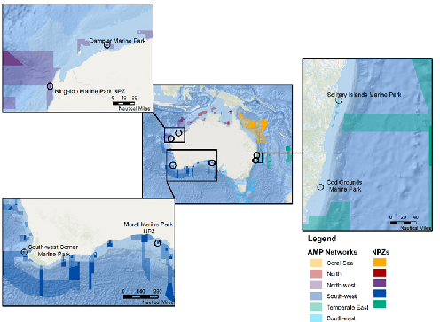

Figure 1: Overview map of all deployments as of 05/2021.

We are currently using a hybrid analytical approach which combines an automated detector with  
manual review of a long-term spectral average (LTSA) to maximize the number of detected  
vessels. For each vessel detection, we review the finer-scale spectrogram to determine more  
precise duration and vessel behavior. After the initial selections have been made, we also use a basic transmission loss model to estimate possible source levels and ranges of each vessel in order to determine how many vessels are likely to occur within the NPZ boundaries.

#### Raven Presets Used in Vessel Analysis

Page Sound:

- Page size: 180 seconds
- Page increment: 90 percent
- Step increment: 10 percent

File name template: .<yy><ll><dd><hh><mm><ss>

Brightness: 44  
Contrast: 71  
FFT: 4096  
0-10 kHz

EP D2b 6/13/2019 as example

### AMP Dolphin [Protocol](https://drive.google.com/file/d/1z_GhQgUzVuB1FB6oj2nwY_4MbkTL4C2h/view?usp=sharing)

### Australian Marine Parks Manual Browsing [Protocol](https://docs.google.com/document/d/1GCB03ar67OdLvRkWYYsghf9siJYUBfSV/edit?usp=sharing&ouid=116688690465000616014&rtpof=true&sd=true)